# Interim Data Analysis : Associations with Adult Orbital Cellulitis

Ryan Summers

2026-04-19

## 1 Introduction

> Orbital cellulitis (OC) is a serious infection of the orbital tissues that can lead to vision-threatening and life-threatening complications, often requiring hospitalization and, in severe cases, surgical intervention. Clinical presentations can vary, ranging from localized inflammation to the development of orbital and intracranial complications such as subperiosteal abscess (SPA), orbital abscess (OA), and intracranial extension (ICE).

> The data for these analyses consist of hospital admissions for OC from June 2006 through May 2025, derived from a retrospective chart review across three hospital systems: Denver Health (DH), University of Colorado (UC), and Oregon Health and Science University (OHSU). The dataset includes 330 adult subjects with detailed clinical, demographic, and outcome information collected at the time of admission.

> The primary objectives of this analysis were to identify factors associated with need for surgical intervention and length of hospital stay (LOS) among adults admitted for orbital cellulitis. Secondary analyses examined factors associated with the development of complications, including SPA, OA, and ICE. We hypothesized that markers of disease severity and underlying comorbidities would be associated with increased likelihood of surgery and prolonged LOS.

## 2 Methods

- OR - relates to probability of an event
- RR - relates to amount of something (counts/time)
  - OR=2 ≠ RR=2 - OR is usually more extreme when event is more common

Logistic regression models estimated odds ratios (ORs) for binary outcomes, representing the relative odds of an event. Negative binomial models estimated rate ratios (RRs) for length of stay, representing multiplicative changes in expected LOS.

### 2.1 Data Management & Cleanup

```r
oc_raw <- read_excel("/Users/ryan_summers/Library/Mobile\ Documents/com~apple~CloudDocs/GitHub/Orbital-Cellulitis-Research/adult_analysis/DataRaw/OHSU\ and\ UC.xlsx", sheet="Adults")
```

A priori variables based on discussion with PI

```r
priori <- c("age", "sinusitis", "diabetes", "immunocompromise", "drug/alc",
            "asthma", "trauma", "prior_surgery", "surgery_adm",
            "dental_infection",  "nldo/infection", "spa", "oa", "ice")
```

```r
# cleanup column names
oc_cleaned <- oc_raw %>%
  # lowercase columns & rows & remove white-space in columns
    setNames(names(.) |> tolower() |> gsub("\\s+", "_", x = _) |>
               make.unique(sep = "_dup_")) %>%
  # lower case and remove white-space from rows
  mutate(across(where(is.character), \(x) str_squish(tolower(x)))) %>%
  # for stability mark other sex as NA since its only one case
  mutate(sex = ifelse(sex == "other", NA, sex),
         # re-calculate age variable (og is AAA)
         age = as.numeric(difftime(doa, dob, units = "days") / 365.25),
         sex = factor(sex, levels = c(0,1), labels = c("Female", "Male"))) %>%
  # relocate age
  relocate(age, .after = doa) %>%
  # rename(oc_adm = orbital_cellulitis_admissions,
  #        rv_ev = `rv/ev`) %>%
  # remove last two rows containing summaries
  filter(!is.na(record_id)) %>%
  # rename duplicate surgery variables
  rename(
    prior_surgery = surgery...28,
    surgery_adm = surgery...61) %>%
  # convert variables to factors
  mutate(across(all_of(priori[priori != "age"]),
                ~ factor(.x, levels = c(0, 1), labels = c("No", "Yes"))),
         # collapse race/ethnicity into one column vector
         race_eth = case_when(
           hl == 1 ~ "Hispanic",
           nonhl == 1 & white == 1 ~ "White non-Hispanic",
           nonhl == 1 & black == 1 ~ "Black non-Hispanic",
           nonhl == 1 & `asian/pi`== 1 & native_american == 1 & other...10 == 1
           ~ "Other",
           TRUE ~ NA_character_))

# duplicate names
# which(names(oc_cleaned) == "surgery")
# names(oc_cleaned)[grepl("surgery", names(oc_cleaned))]
```

```r
# find duplicated column names
names(oc_raw)[duplicated(names(oc_raw))]
```

```
## character(0)
```

```r
which(duplicated(names(oc_raw)))
```

```
## integer(0)
```

```r
# check where in my pipeline its creating a duplicate
n1 <- names(oc_raw)
n2 <- tolower(n1)
n3 <- gsub("\\s+", "_", n2)

n1[duplicated(n1)]
```

```
## character(0)
```

```r
n2[duplicated(n2)]
```

```
## [1] "pseudo"
```

```r
n3[duplicated(n3)]
```

```
## [1] "pseudo"
```

> The race/ethnicity covariate was categorized as White non-Hispanic, Black non-Hispanic, and Hispanic. We acknowledge that race is a social construct and that observed differences likely reflect structural inequities rather than biological differences.

### 2.2 Exploratory Data Analysis (EDA)

```r
tbl1 <- oc_cleaned %>%
  tbl_summary(
    by = surgery_adm,
    include = c(
      age, sex, race_eth, sinusitis, diabetes, immunocompromise, `drug/alc`,
      asthma, trauma, prior_surgery, dental_infection, `nldo/infection`,
      spa, oa, ice, los),
    type = list(
      all_continuous() ~ "continuous2",
      all_categorical() ~ "categorical"),
    statistic = list(
      all_continuous() ~ c(
        "{mean} ({sd})",
        "{median} [{p25}, {p75}]",
        "{min} - {max}"),
      all_categorical() ~ "{n} ({p}%)"),
    #igits = list(AGE ~ 0, SYSBP ~ 0),
    missing = "ifany",
    missing_text = "NA",
    missing_stat = "{N_miss} ({p_miss}%)",
    label = list(
      age ~ "Age",
      sex ~ "Sex",
      race_eth ~ "Race/Ethnicity",
      sinusitis ~ "Sinusitis",
      diabetes ~ "Diabetes",
      immunocompromise ~ "Immunocompromise",
      `drug/alc` ~ "Drug/Alcohol",
      asthma ~ "Asthma",
      trauma ~ "Trauma",
      prior_surgery ~ "Prior Surgery",
      dental_infection ~ "Dental",
      `nldo/infection`~ "NLDO",
      spa ~ "SPA",
      oa ~ "OA",
      ice ~ "ICE",
      los ~ "Length of Stay"
      )) %>%
  add_overall() %>% bold_labels() %>% italicize_levels() %>% add_n() %>%
  modify_spanning_header(
    c("stat_1", "stat_2") ~ "**Surgery Needed**") %>%
  as_gt() %>%
  gt::fmt_markdown(columns = everything()) %>%
  tab_header(
    title = "Characteristics of Orbital Cellulitis Adult Cohort") %>%
  tab_source_note(
    source_note = "Percentages are calculated within levels of the stratifying
    variable") %>%
  tab_options(
    table.width = pct(70),
    table.font.size = "small",
    heading.align = "left",
    data_row.padding = px(3),
    table.border.top.width = px(2),
    table.border.bottom.width = px(2))

tbl1
```

Characteristics of Orbital Cellulitis Adult Cohort

| **Characteristic** | **N** | **Overall** N = 330<sup>1</sup> | **Surgery Needed** **No** N = 137<sup>1</sup> | **Surgery Needed** **Yes** N = 193<sup>1</sup> |
| --- | --- | --- | --- | --- |
| Age | 330 |  |  |  |
| Mean (SD) |  | 49 (19) | 49 (19) | 50 (19) |
| Median [Q1, Q3] |  | 49 [34, 64] | 48 [32, 65] | 51 [35, 64] |
| Min - Max |  | 18 - 94 | 19 - 93 | 18 - 94 |
| Sex | 329 |  |  |  |
| Female |  | 122 (37%) | 54 (39%) | 68 (35%) |
| Male |  | 207 (63%) | 83 (61%) | 124 (65%) |
| NA |  | 1 (0.3%) | 0 (0%) | 1 (0.5%) |
| Race/Ethnicity | 298 |  |  |  |
| Black non-Hispanic |  | 19 (6.4%) | 9 (7.3%) | 10 (5.7%) |
| Hispanic |  | 47 (16%) | 18 (15%) | 29 (17%) |
| White non-Hispanic |  | 232 (78%) | 96 (78%) | 136 (78%) |
| NA |  | 32 (9.7%) | 14 (10%) | 18 (9.3%) |
| Sinusitis | 330 |  |  |  |
| No |  | 145 (44%) | 76 (55%) | 69 (36%) |
| Yes |  | 185 (56%) | 61 (45%) | 124 (64%) |
| Diabetes | 330 |  |  |  |
| No |  | 272 (82%) | 119 (87%) | 153 (79%) |
| Yes |  | 58 (18%) | 18 (13%) | 40 (21%) |
| Immunocompromise | 330 |  |  |  |
| No |  | 280 (85%) | 115 (84%) | 165 (85%) |
| Yes |  | 50 (15%) | 22 (16%) | 28 (15%) |
| Drug/Alcohol | 330 |  |  |  |
| No |  | 280 (85%) | 116 (85%) | 164 (85%) |
| Yes |  | 50 (15%) | 21 (15%) | 29 (15%) |
| Asthma | 330 |  |  |  |
| No |  | 311 (94%) | 128 (93%) | 183 (95%) |
| Yes |  | 19 (5.8%) | 9 (6.6%) | 10 (5.2%) |
| Trauma | 330 |  |  |  |
| No |  | 283 (86%) | 116 (85%) | 167 (87%) |
| Yes |  | 47 (14%) | 21 (15%) | 26 (13%) |
| Prior Surgery | 330 |  |  |  |
| No |  | 297 (90%) | 123 (90%) | 174 (90%) |
| Yes |  | 33 (10%) | 14 (10%) | 19 (9.8%) |
| Dental | 330 |  |  |  |
| No |  | 308 (93%) | 128 (93%) | 180 (93%) |
| Yes |  | 22 (6.7%) | 9 (6.6%) | 13 (6.7%) |
| NLDO | 330 |  |  |  |
| No |  | 323 (98%) | 133 (97%) | 190 (98%) |
| Yes |  | 7 (2.1%) | 4 (2.9%) | 3 (1.6%) |
| SPA | 330 |  |  |  |
| No |  | 262 (79%) | 134 (98%) | 128 (66%) |
| Yes |  | 68 (21%) | 3 (2.2%) | 65 (34%) |
| OA | 330 |  |  |  |
| No |  | 278 (84%) | 125 (91%) | 153 (79%) |
| Yes |  | 52 (16%) | 12 (8.8%) | 40 (21%) |
| ICE | 330 |  |  |  |
| No |  | 315 (95%) | 134 (98%) | 181 (94%) |
| Yes |  | 15 (4.5%) | 3 (2.2%) | 12 (6.2%) |
| Length of Stay | 327 |  |  |  |
| Mean (SD) |  | 7 (8) | 5 (5) | 9 (8) |
| Median [Q1, Q3] |  | 5 [3, 9] | 3 [2, 5] | 7 [4, 11] |
| Min - Max |  | 0 - 56 | 0 - 33 | 1 - 56 |
| NA |  | 3 (0.9%) | 1 (0.7%) | 2 (1.0%) |

<sup>1</sup> n (%)  
Percentages are calculated within levels of the stratifying variable

```r
tbl2 <- oc_cleaned %>%
  tbl_summary(
    by = spa,
    include = c(
      age, sex, race_eth, sinusitis, diabetes, immunocompromise, `drug/alc`,
      asthma, trauma, prior_surgery, dental_infection, `nldo/infection`,
      oa, ice, los, surgery_adm),
    type = list(
      all_continuous() ~ "continuous2",
      all_categorical() ~ "categorical"),
    statistic = list(
      all_continuous() ~ c(
        "{mean} ({sd})",
        "{median} [{p25}, {p75}]",
        "{min} - {max}"),
      all_categorical() ~ "{n} ({p}%)"),
    #igits = list(AGE ~ 0, SYSBP ~ 0),
    missing = "ifany",
    missing_text = "NA",
    missing_stat = "{N_miss} ({p_miss}%)",
    label = list(
      age ~ "Age",
      sex ~ "Sex",
      race_eth ~ "Race/Ethnicity",
      sinusitis ~ "Sinusitis",
      diabetes ~ "Diabetes",
      immunocompromise ~ "Immunocompromise",
      `drug/alc` ~ "Drug/Alcohol",
      asthma ~ "Asthma",
      trauma ~ "Trauma",
      prior_surgery ~ "Prior Surgery",
      dental_infection ~ "Dental",
      `nldo/infection`~ "NLDO",
      surgery_adm ~ "Surgery during admission",
      oa ~ "OA",
      ice ~ "ICE",
      los ~ "Length of Stay"
      )) %>%
  add_overall() %>% bold_labels() %>% italicize_levels() %>% add_n() %>%
  modify_spanning_header(
    c("stat_1", "stat_2") ~ "**SPA**") %>%
  as_gt() %>%
  gt::fmt_markdown(columns = everything()) %>%
  tab_header(
    title = "Characteristics of Orbital Cellulitis Adult Cohort") %>%
    tab_source_note(
    source_note = "Percentages are calculated within levels of the stratifying
    variable") %>%
  tab_options(
    table.width = pct(70),
    table.font.size = "small",
    heading.align = "left",
    data_row.padding = px(3),
    table.border.top.width = px(2),
    table.border.bottom.width = px(2))

tbl2
```

Characteristics of Orbital Cellulitis Adult Cohort

| **Characteristic** | **N** | **Overall** N = 330<sup>1</sup> | **SPA** **No** N = 262<sup>1</sup> | **SPA** **Yes** N = 68<sup>1</sup> |
| --- | --- | --- | --- | --- |
| Age | 330 |  |  |  |
| Mean (SD) |  | 49 (19) | 51 (19) | 42 (19) |
| Median [Q1, Q3] |  | 49 [34, 64] | 52 [35, 66] | 38 [24, 57] |
| Min - Max |  | 18 - 94 | 19 - 94 | 18 - 80 |
| Sex | 329 |  |  |  |
| Female |  | 122 (37%) | 103 (39%) | 19 (28%) |
| Male |  | 207 (63%) | 159 (61%) | 48 (72%) |
| NA |  | 1 (0.3%) | 0 (0%) | 1 (1.5%) |
| Race/Ethnicity | 298 |  |  |  |
| Black non-Hispanic |  | 19 (6.4%) | 14 (5.9%) | 5 (8.1%) |
| Hispanic |  | 47 (16%) | 36 (15%) | 11 (18%) |
| White non-Hispanic |  | 232 (78%) | 186 (79%) | 46 (74%) |
| NA |  | 32 (9.7%) | 26 (9.9%) | 6 (8.8%) |
| Sinusitis | 330 |  |  |  |
| No |  | 145 (44%) | 140 (53%) | 5 (7.4%) |
| Yes |  | 185 (56%) | 122 (47%) | 63 (93%) |
| Diabetes | 330 |  |  |  |
| No |  | 272 (82%) | 209 (80%) | 63 (93%) |
| Yes |  | 58 (18%) | 53 (20%) | 5 (7.4%) |
| Immunocompromise | 330 |  |  |  |
| No |  | 280 (85%) | 216 (82%) | 64 (94%) |
| Yes |  | 50 (15%) | 46 (18%) | 4 (5.9%) |
| Drug/Alcohol | 330 |  |  |  |
| No |  | 280 (85%) | 222 (85%) | 58 (85%) |
| Yes |  | 50 (15%) | 40 (15%) | 10 (15%) |
| Asthma | 330 |  |  |  |
| No |  | 311 (94%) | 247 (94%) | 64 (94%) |
| Yes |  | 19 (5.8%) | 15 (5.7%) | 4 (5.9%) |
| Trauma | 330 |  |  |  |
| No |  | 283 (86%) | 219 (84%) | 64 (94%) |
| Yes |  | 47 (14%) | 43 (16%) | 4 (5.9%) |
| Prior Surgery | 330 |  |  |  |
| No |  | 297 (90%) | 233 (89%) | 64 (94%) |
| Yes |  | 33 (10%) | 29 (11%) | 4 (5.9%) |
| Dental | 330 |  |  |  |
| No |  | 308 (93%) | 247 (94%) | 61 (90%) |
| Yes |  | 22 (6.7%) | 15 (5.7%) | 7 (10%) |
| NLDO | 330 |  |  |  |
| No |  | 323 (98%) | 255 (97%) | 68 (100%) |
| Yes |  | 7 (2.1%) | 7 (2.7%) | 0 (0%) |
| OA | 330 |  |  |  |
| No |  | 278 (84%) | 210 (80%) | 68 (100%) |
| Yes |  | 52 (16%) | 52 (20%) | 0 (0%) |
| ICE | 330 |  |  |  |
| No |  | 315 (95%) | 251 (96%) | 64 (94%) |
| Yes |  | 15 (4.5%) | 11 (4.2%) | 4 (5.9%) |
| Length of Stay | 327 |  |  |  |
| Mean (SD) |  | 7 (8) | 7 (8) | 7 (6) |
| Median [Q1, Q3] |  | 5 [3, 9] | 5 [3, 9] | 6 [4, 9] |
| Min - Max |  | 0 - 56 | 0 - 56 | 2 - 40 |
| NA |  | 3 (0.9%) | 3 (1.1%) | 0 (0%) |
| Surgery during admission | 330 |  |  |  |
| No |  | 137 (42%) | 134 (51%) | 3 (4.4%) |
| Yes |  | 193 (58%) | 128 (49%) | 65 (96%) |

<sup>1</sup> n (%)  
Percentages are calculated within levels of the stratifying variable

```r
tbl3 <- oc_cleaned %>%
  tbl_summary(
    by = oa,
    include = c(
      age, sex, race_eth, sinusitis, diabetes, immunocompromise, `drug/alc`,
      asthma, trauma, prior_surgery, dental_infection, `nldo/infection`,
      spa, ice, los, surgery_adm),
    type = list(
      all_continuous() ~ "continuous2",
      all_categorical() ~ "categorical"),
    statistic = list(
      all_continuous() ~ c(
        "{mean} ({sd})",
        "{median} [{p25}, {p75}]",
        "{min} - {max}"),
      all_categorical() ~ "{n} ({p}%)"),
    #igits = list(AGE ~ 0, SYSBP ~ 0),
    missing = "ifany",
    missing_text = "NA",
    missing_stat = "{N_miss} ({p_miss}%)",
    label = list(
      age ~ "Age",
      sex ~ "Sex",
      race_eth ~ "Race/Ethnicity",
      sinusitis ~ "Sinusitis",
      diabetes ~ "Diabetes",
      immunocompromise ~ "Immunocompromise",
      `drug/alc` ~ "Drug/Alcohol",
      asthma ~ "Asthma",
      trauma ~ "Trauma",
      prior_surgery ~ "Prior Surgery",
      dental_infection ~ "Dental",
      `nldo/infection`~ "NLDO",
      surgery_adm ~ "Surgery during admission",
      spa ~ "SPA",
      ice ~ "ICE",
      los ~ "Length of Stay"
      )) %>%
  add_overall() %>% bold_labels() %>% italicize_levels() %>% add_n() %>%
  modify_spanning_header(
    c("stat_1", "stat_2") ~ "**OA**") %>%
  as_gt() %>%
  gt::fmt_markdown(columns = everything()) %>%
  tab_header(
    title = "Characteristics of Orbital Cellulitis Adult Cohort") %>%
    tab_source_note(
    source_note = "Percentages are calculated within levels of the stratifying
    variable") %>%
  tab_options(
    table.width = pct(70),
    table.font.size = "small",
    heading.align = "left",
    data_row.padding = px(3),
    table.border.top.width = px(2),
    table.border.bottom.width = px(2))

tbl3
```

Characteristics of Orbital Cellulitis Adult Cohort

| **Characteristic** | **N** | **Overall** N = 330<sup>1</sup> | **OA** **No** N = 278<sup>1</sup> | **OA** **Yes** N = 52<sup>1</sup> |
| --- | --- | --- | --- | --- |
| Age | 330 |  |  |  |
| Mean (SD) |  | 49 (19) | 49 (19) | 54 (20) |
| Median [Q1, Q3] |  | 49 [34, 64] | 49 [33, 64] | 55 [39, 68] |
| Min - Max |  | 18 - 94 | 18 - 90 | 19 - 94 |
| Sex | 329 |  |  |  |
| Female |  | 122 (37%) | 94 (34%) | 28 (54%) |
| Male |  | 207 (63%) | 183 (66%) | 24 (46%) |
| NA |  | 1 (0.3%) | 1 (0.4%) | 0 (0%) |
| Race/Ethnicity | 298 |  |  |  |
| Black non-Hispanic |  | 19 (6.4%) | 18 (7.1%) | 1 (2.2%) |
| Hispanic |  | 47 (16%) | 39 (15%) | 8 (17%) |
| White non-Hispanic |  | 232 (78%) | 195 (77%) | 37 (80%) |
| NA |  | 32 (9.7%) | 26 (9.4%) | 6 (12%) |
| Sinusitis | 330 |  |  |  |
| No |  | 145 (44%) | 107 (38%) | 38 (73%) |
| Yes |  | 185 (56%) | 171 (62%) | 14 (27%) |
| Diabetes | 330 |  |  |  |
| No |  | 272 (82%) | 226 (81%) | 46 (88%) |
| Yes |  | 58 (18%) | 52 (19%) | 6 (12%) |
| Immunocompromise | 330 |  |  |  |
| No |  | 280 (85%) | 233 (84%) | 47 (90%) |
| Yes |  | 50 (15%) | 45 (16%) | 5 (9.6%) |
| Drug/Alcohol | 330 |  |  |  |
| No |  | 280 (85%) | 235 (85%) | 45 (87%) |
| Yes |  | 50 (15%) | 43 (15%) | 7 (13%) |
| Asthma | 330 |  |  |  |
| No |  | 311 (94%) | 262 (94%) | 49 (94%) |
| Yes |  | 19 (5.8%) | 16 (5.8%) | 3 (5.8%) |
| Trauma | 330 |  |  |  |
| No |  | 283 (86%) | 242 (87%) | 41 (79%) |
| Yes |  | 47 (14%) | 36 (13%) | 11 (21%) |
| Prior Surgery | 330 |  |  |  |
| No |  | 297 (90%) | 251 (90%) | 46 (88%) |
| Yes |  | 33 (10%) | 27 (9.7%) | 6 (12%) |
| Dental | 330 |  |  |  |
| No |  | 308 (93%) | 258 (93%) | 50 (96%) |
| Yes |  | 22 (6.7%) | 20 (7.2%) | 2 (3.8%) |
| NLDO | 330 |  |  |  |
| No |  | 323 (98%) | 271 (97%) | 52 (100%) |
| Yes |  | 7 (2.1%) | 7 (2.5%) | 0 (0%) |
| SPA | 330 |  |  |  |
| No |  | 262 (79%) | 210 (76%) | 52 (100%) |
| Yes |  | 68 (21%) | 68 (24%) | 0 (0%) |
| ICE | 330 |  |  |  |
| No |  | 315 (95%) | 265 (95%) | 50 (96%) |
| Yes |  | 15 (4.5%) | 13 (4.7%) | 2 (3.8%) |
| Length of Stay | 327 |  |  |  |
| Mean (SD) |  | 7 (8) | 7 (7) | 8 (10) |
| Median [Q1, Q3] |  | 5 [3, 9] | 5 [3, 9] | 5 [4, 7] |
| Min - Max |  | 0 - 56 | 0 - 47 | 1 - 56 |
| NA |  | 3 (0.9%) | 3 (1.1%) | 0 (0%) |
| Surgery during admission | 330 |  |  |  |
| No |  | 137 (42%) | 125 (45%) | 12 (23%) |
| Yes |  | 193 (58%) | 153 (55%) | 40 (77%) |

<sup>1</sup> n (%)  
Percentages are calculated within levels of the stratifying variable

```r
tbl4 <- oc_cleaned %>%
  tbl_summary(
    by = ice,
    include = c(
      age, sex, race_eth, sinusitis, diabetes, immunocompromise, `drug/alc`,
      asthma, trauma, prior_surgery, dental_infection, `nldo/infection`,
      oa, spa, los, surgery_adm),
    type = list(
      all_continuous() ~ "continuous2",
      all_categorical() ~ "categorical"),
    statistic = list(
      all_continuous() ~ c(
        "{mean} ({sd})",
        "{median} [{p25}, {p75}]",
        "{min} - {max}"),
      all_categorical() ~ "{n} ({p}%)"),
    #igits = list(AGE ~ 0, SYSBP ~ 0),
    missing = "ifany",
    missing_text = "NA",
    missing_stat = "{N_miss} ({p_miss}%)",
    label = list(
      age ~ "Age",
      sex ~ "Sex",
      race_eth ~ "Race/Ethnicity",
      sinusitis ~ "Sinusitis",
      diabetes ~ "Diabetes",
      immunocompromise ~ "Immunocompromise",
      `drug/alc` ~ "Drug/Alcohol",
      asthma ~ "Asthma",
      trauma ~ "Trauma",
      prior_surgery ~ "Prior Surgery",
      dental_infection ~ "Dental",
      `nldo/infection`~ "NLDO",
      surgery_adm ~ "Surgery during admission",
      oa ~ "OA",
      spa ~ "SPA",
      los ~ "Length of Stay"
      )) %>%
  add_overall() %>% bold_labels() %>% italicize_levels() %>% add_n() %>%
  modify_spanning_header(
    c("stat_1", "stat_2") ~ "**ICE**") %>%
  as_gt() %>%
  gt::fmt_markdown(columns = everything()) %>%
  tab_header(
    title = "Characteristics of Orbital Cellulitis Adult Cohort") %>%
    tab_source_note(
    source_note = "Percentages are calculated within levels of the stratifying
    variable") %>%
  tab_options(
    table.width = pct(70),
    table.font.size = "small",
    heading.align = "left",
    data_row.padding = px(3),
    table.border.top.width = px(2),
    table.border.bottom.width = px(2))

tbl4
```

Characteristics of Orbital Cellulitis Adult Cohort

| **Characteristic** | **N** | **Overall** N = 330<sup>1</sup> | **ICE** **No** N = 315<sup>1</sup> | **ICE** **Yes** N = 15<sup>1</sup> |
| --- | --- | --- | --- | --- |
| Age | 330 |  |  |  |
| Mean (SD) |  | 49 (19) | 50 (19) | 41 (16) |
| Median [Q1, Q3] |  | 49 [34, 64] | 50 [34, 65] | 41 [24, 57] |
| Min - Max |  | 18 - 94 | 18 - 94 | 20 - 62 |
| Sex | 329 |  |  |  |
| Female |  | 122 (37%) | 117 (37%) | 5 (33%) |
| Male |  | 207 (63%) | 197 (63%) | 10 (67%) |
| NA |  | 1 (0.3%) | 1 (0.3%) | 0 (0%) |
| Race/Ethnicity | 298 |  |  |  |
| Black non-Hispanic |  | 19 (6.4%) | 19 (6.6%) | 0 (0%) |
| Hispanic |  | 47 (16%) | 46 (16%) | 1 (9.1%) |
| White non-Hispanic |  | 232 (78%) | 222 (77%) | 10 (91%) |
| NA |  | 32 (9.7%) | 28 (8.9%) | 4 (27%) |
| Sinusitis | 330 |  |  |  |
| No |  | 145 (44%) | 143 (45%) | 2 (13%) |
| Yes |  | 185 (56%) | 172 (55%) | 13 (87%) |
| Diabetes | 330 |  |  |  |
| No |  | 272 (82%) | 261 (83%) | 11 (73%) |
| Yes |  | 58 (18%) | 54 (17%) | 4 (27%) |
| Immunocompromise | 330 |  |  |  |
| No |  | 280 (85%) | 265 (84%) | 15 (100%) |
| Yes |  | 50 (15%) | 50 (16%) | 0 (0%) |
| Drug/Alcohol | 330 |  |  |  |
| No |  | 280 (85%) | 270 (86%) | 10 (67%) |
| Yes |  | 50 (15%) | 45 (14%) | 5 (33%) |
| Asthma | 330 |  |  |  |
| No |  | 311 (94%) | 296 (94%) | 15 (100%) |
| Yes |  | 19 (5.8%) | 19 (6.0%) | 0 (0%) |
| Trauma | 330 |  |  |  |
| No |  | 283 (86%) | 269 (85%) | 14 (93%) |
| Yes |  | 47 (14%) | 46 (15%) | 1 (6.7%) |
| Prior Surgery | 330 |  |  |  |
| No |  | 297 (90%) | 282 (90%) | 15 (100%) |
| Yes |  | 33 (10%) | 33 (10%) | 0 (0%) |
| Dental | 330 |  |  |  |
| No |  | 308 (93%) | 294 (93%) | 14 (93%) |
| Yes |  | 22 (6.7%) | 21 (6.7%) | 1 (6.7%) |
| NLDO | 330 |  |  |  |
| No |  | 323 (98%) | 308 (98%) | 15 (100%) |
| Yes |  | 7 (2.1%) | 7 (2.2%) | 0 (0%) |
| OA | 330 |  |  |  |
| No |  | 278 (84%) | 265 (84%) | 13 (87%) |
| Yes |  | 52 (16%) | 50 (16%) | 2 (13%) |
| SPA | 330 |  |  |  |
| No |  | 262 (79%) | 251 (80%) | 11 (73%) |
| Yes |  | 68 (21%) | 64 (20%) | 4 (27%) |
| Length of Stay | 327 |  |  |  |
| Mean (SD) |  | 7 (8) | 7 (7) | 16 (11) |
| Median [Q1, Q3] |  | 5 [3, 9] | 5 [3, 8] | 13 [6, 24] |
| Min - Max |  | 0 - 56 | 0 - 56 | 6 - 40 |
| NA |  | 3 (0.9%) | 3 (1.0%) | 0 (0%) |
| Surgery during admission | 330 |  |  |  |
| No |  | 137 (42%) | 134 (43%) | 3 (20%) |
| Yes |  | 193 (58%) | 181 (57%) | 12 (80%) |

<sup>1</sup> n (%)  
Percentages are calculated within levels of the stratifying variable

```r
tbl1 <- oc_cleaned %>%
  tbl_summary(
    by = surgery_adm,
    include = c(
      age, sex, race_eth, sinusitis, diabetes, immunocompromise, `drug/alc`,
      asthma, trauma, prior_surgery, dental_infection, `nldo/infection`,
      spa, oa, ice, los),
    type = list(
      age ~ "continuous",
      los ~ "continuous",
      c(sinusitis, diabetes, immunocompromise, `drug/alc`,
        asthma, trauma, prior_surgery, dental_infection,
        `nldo/infection`, spa, oa, ice) ~ "dichotomous",
      c(race_eth, sex) ~ "categorical"),
    value = list(
      sex ~ "Male",
      sinusitis ~ "Yes",
      diabetes ~ "Yes",
      immunocompromise ~ "Yes",
      `drug/alc` ~ "Yes",
      asthma ~ "Yes",
      trauma ~ "Yes",
      prior_surgery ~ "Yes",
      dental_infection ~ "Yes",
      `nldo/infection` ~ "Yes",
      spa ~ "Yes",
      oa ~ "Yes",
      ice ~ "Yes"),
    statistic = list(
      all_continuous() ~ "{median} ({p25}, {p75})",
      all_categorical() ~ "{n} ({p}%)",
      all_dichotomous() ~ "{n} ({p}%)"),
    missing = "no",
    label = list(
      age ~ "Age",
      sex ~ "Sex",
      race_eth ~ "Race/Ethnicity",
      sinusitis ~ "Sinusitis",
      diabetes ~ "Diabetes",
      immunocompromise ~ "Immunocompromised",
      `drug/alc` ~ "Drug/Alcohol use",
      asthma ~ "Asthma",
      trauma ~ "Trauma",
      prior_surgery ~ "Prior surgery",
      dental_infection ~ "Dental infection",
      `nldo/infection` ~ "NLDO",
      spa ~ "SPA",
      oa ~ "OA",
      ice ~ "ICE",
      los ~ "Length of stay")) %>%
  add_overall() %>% add_n() %>% bold_labels() %>%
  modify_spanning_header(c("stat_1", "stat_2") ~ "**Surgery Needed**") %>%
  as_gt() %>%
  gt::fmt_markdown(columns = everything()) %>%
  tab_header(title = "Characteristics of Adult Orbital Cellulitis Admissions") %>%
  tab_options(
    table.width = pct(70),
    table.font.size = "small",
    heading.align = "left",
    data_row.padding = px(3),
    table.border.top.width = px(2),
    table.border.bottom.width = px(2))

tbl1
```

Characteristics of Adult Orbital Cellulitis Admissions

| **Characteristic** | **N** | **Overall** N = 330<sup>1</sup> | **Surgery Needed** **No** N = 137<sup>1</sup> | **Surgery Needed** **Yes** N = 193<sup>1</sup> |
| --- | --- | --- | --- | --- |
| Age | 330 | 49 (34, 64) | 48 (32, 65) | 51 (35, 64) |
| Sex | 329 |  |  |  |
| Female |  | 122 (37%) | 54 (39%) | 68 (35%) |
| Male |  | 207 (63%) | 83 (61%) | 124 (65%) |
| Race/Ethnicity | 298 |  |  |  |
| Black non-Hispanic |  | 19 (6.4%) | 9 (7.3%) | 10 (5.7%) |
| Hispanic |  | 47 (16%) | 18 (15%) | 29 (17%) |
| White non-Hispanic |  | 232 (78%) | 96 (78%) | 136 (78%) |
| Sinusitis | 330 | 185 (56%) | 61 (45%) | 124 (64%) |
| Diabetes | 330 | 58 (18%) | 18 (13%) | 40 (21%) |
| Immunocompromised | 330 | 50 (15%) | 22 (16%) | 28 (15%) |
| Drug/Alcohol use | 330 | 50 (15%) | 21 (15%) | 29 (15%) |
| Asthma | 330 | 19 (5.8%) | 9 (6.6%) | 10 (5.2%) |
| Trauma | 330 | 47 (14%) | 21 (15%) | 26 (13%) |
| Prior surgery | 330 | 33 (10%) | 14 (10%) | 19 (9.8%) |
| Dental infection | 330 | 22 (6.7%) | 9 (6.6%) | 13 (6.7%) |
| NLDO | 330 | 7 (2.1%) | 4 (2.9%) | 3 (1.6%) |
| SPA | 330 | 68 (21%) | 3 (2.2%) | 65 (34%) |
| OA | 330 | 52 (16%) | 12 (8.8%) | 40 (21%) |
| ICE | 330 | 15 (4.5%) | 3 (2.2%) | 12 (6.2%) |
| Length of stay | 327 | 5 (3, 9) | 3 (2, 5) | 7 (4, 11) |

<sup>1</sup> Median (Q1, Q3); n (%)

```r
# change label names for hospitals
unique(oc_cleaned$hospital)
```

```
## [1] "dh"   "ohsu" "uch"
```

Number of patients

```r
cat("Number of patients:",
  length(unique(oc_cleaned$record_id)),"\n\n")
```

```
## Number of patients: 330
```

Missing values

```r
oc_cleaned %>% ungroup() %>% miss_var_summary()
```

```
## # A tibble: 120 × 3
##    variable                          n_miss pct_miss
##    <chr>                              <int>    <num>
##  1 anticoagulation_initiated?           324     98.2
##  2 type_of_anticoagulation_initiated    324     98.2
##  3 type_of_intracranial_extension       315     95.5
##  4 new_findings_on_repeat_imaging       303     91.8
##  5 date_of_prior_surgery                298     90.3
##  6 drsx                                 298     90.3
##  7 type_of_prior_surgery                297     90
##  8 other_on_imaging_-_explanation       294     89.1
##  9 post_va_(20/***)                     292     88.5
## 10 date_of_trauma                       286     86.7
## # ℹ 110 more rows
```

```r
# missing values for predictors of interest
oc_cleaned[, priori] %>% ungroup() %>% miss_var_summary()
```

```
## # A tibble: 14 × 3
##    variable         n_miss pct_miss
##    <chr>             <int>    <num>
##  1 age                   0        0
##  2 sinusitis             0        0
##  3 diabetes              0        0
##  4 immunocompromise      0        0
##  5 drug/alc              0        0
##  6 asthma                0        0
##  7 trauma                0        0
##  8 prior_surgery         0        0
##  9 surgery_adm           0        0
## 10 dental_infection      0        0
## 11 nldo/infection        0        0
## 12 spa                   0        0
## 13 oa                    0        0
## 14 ice                   0        0
```

**NLDO** = Nasolacrimal duct infection: a tear duct inflammation and/or infection, can happen in newborn infants and in adults. Treatment usually includes antibiotics. Surgery is a possible option to stop recurrences.

**Dacryocystitis** is an infection of the tear sac (lacrimal sac) caused by a blockage in the tear duct (nasolacrimal duct), leading to pain, redness, and swelling around the eye. Treatment typically involves antibiotics, and in some cases, surgery may be necessary to relieve the blockage.

Neutrophils = innate, acute inflammation Lymphocytes (T,B,NK) = adaptive, regulated immunity * Neutrophils ↑ = acute inflammation, stress, infection * Lymphocytes ↓ = stress response, immune suppression, chronic disease * So high NLR = More inflammation + relatively weaker adaptive immune response

Physiological meaning of high vs low NLR

High NLR: * Acute stress or infection * Chronic inflammation * Poor prognosis in some diseases

Low NLR: * Lower inflammation * Stronger relative adaptive immunity (context-dependent)

Get group counts

```r
count_grp_obs(oc_cleaned, vars = priori[priori != "age"],
              mode = "separate")
```

```
## # A tibble: 26 × 4
##    variable         category     n   pct
##    <chr>            <chr>    <int> <dbl>
##  1 asthma           No         311 0.942
##  2 asthma           Yes         19 0.058
##  3 dental_infection No         308 0.933
##  4 dental_infection Yes         22 0.067
##  5 diabetes         No         272 0.824
##  6 diabetes         Yes         58 0.176
##  7 drug/alc         No         280 0.848
##  8 drug/alc         Yes         50 0.152
##  9 ice              No         315 0.955
## 10 ice              Yes         15 0.045
## # ℹ 16 more rows
```

```r
sapply(oc_cleaned[priori[priori != "age"]], table)
```

```
##     sinusitis diabetes immunocompromise drug/alc asthma trauma prior_surgery
## No        145      272              280      280    311    283           297
## Yes       185       58               50       50     19     47            33
##     surgery_adm dental_infection nldo/infection spa  oa ice
## No          137              308            323 262 278 315
## Yes         193               22              7  68  52  15
```

Correlations

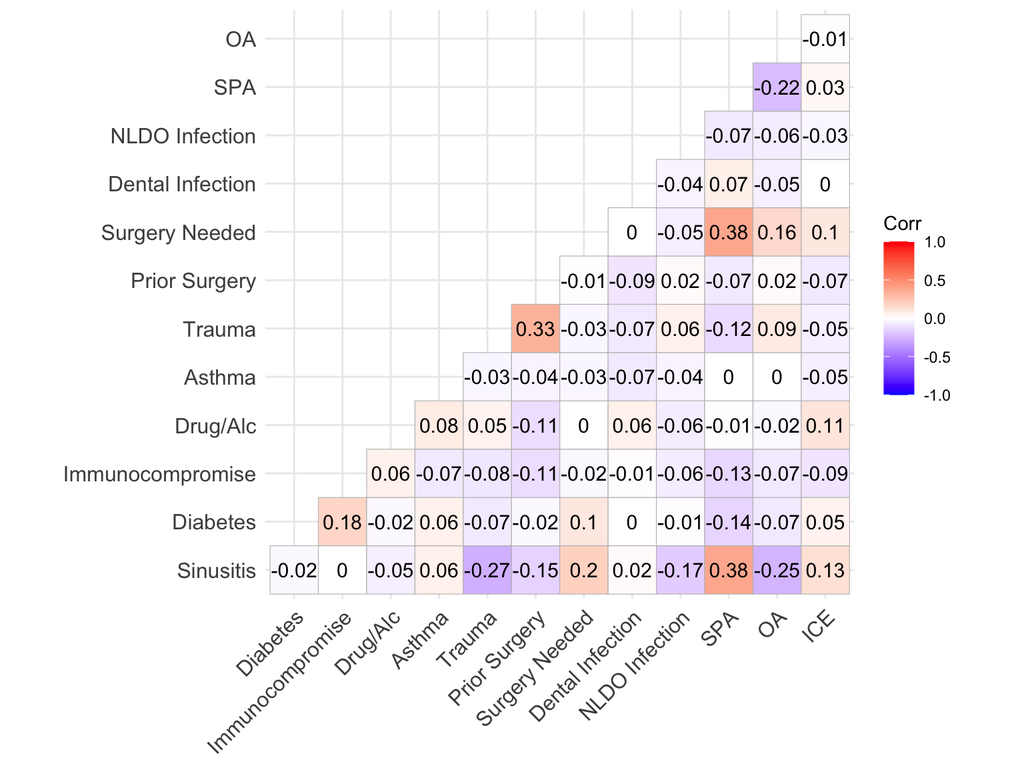

```r
# need to convert back to numeric
X_bin <- oc_cleaned %>%
  dplyr::select(all_of(priori[priori != "age"])) %>%
  mutate(across(everything(), ~ as.numeric(.x) - 1))

clean_names <- c(
  "Sinusitis", "Diabetes", "Immunocompromise", "Drug/Alc",
  "Asthma", "Trauma", "Prior Surgery", "Surgery Needed",
  "Dental Infection", "NLDO Infection", "SPA", "OA", "ICE")

cor_matrix <- cor(X_bin, use = "pairwise.complete.obs", method = "pearson")
colnames(cor_matrix) <- clean_names
rownames(cor_matrix) <- clean_names

ggcorrplot(cor_matrix, type = "lower",lab = T)
```

Per Frank Harrell - Events per varialbe (EPV) ≈ 10 EPV rule $EPV = \frac{\text{Events}}{\text{Predictors}}$

Variable Selection

```r
# form <- surgery_adm ~ .
#
# step.fit <- stepwise(formula = form,
#                 data = oc_cleaned,
#                 type = "logit",
#                 include = c("age", "sex", "race_eth", "sinusitis", "diabetes",
#                             "immunocompromise", "drug/alc", "asthma", "trauma",
#                             "prior_surgery", "dental_infection", "nldo/infection",
#                             "spa", "oa", "ice"),
#                 strategy = "backward",
#                 metric = c("AICc", "SBC"))
#
# summary(step.fit$backward$AICc)
# summary(step.fit$backward$SBC)
# performance(step.fit)
```

```r
# Check unique values and class of each predictor
vars_to_check <- c("age", "sex", "race_eth", "sinusitis", "diabetes",
                   "immunocompromise", "drug/alc", "asthma", "trauma",
                   "prior_surgery", "dental_infection", "nldo/infection",
                   "spa", "oa", "ice")

for (v in vars_to_check) {
  if (v %in% names(oc_cleaned)) {
    cat(v, ":",
        "class =", class(oc_cleaned[[v]]),
        "unique values =", length(unique(na.omit(oc_cleaned[[v]]))),
        "\n")
  } else {
    cat(v, "NOT FOUND in data\n")
  }
}
```

```
## age : class = numeric unique values = 319
## sex : class = factor unique values = 2
## race_eth : class = character unique values = 3
## sinusitis : class = factor unique values = 2
## diabetes : class = factor unique values = 2
## immunocompromise : class = factor unique values = 2
## drug/alc : class = factor unique values = 2
## asthma : class = factor unique values = 2
## trauma : class = factor unique values = 2
## prior_surgery : class = factor unique values = 2
## dental_infection : class = factor unique values = 2
## nldo/infection : class = factor unique values = 2
## spa : class = factor unique values = 2
## oa : class = factor unique values = 2
## ice : class = factor unique values = 2
```

### 2.3 Primary Analysis

#### 2.3.1 Need for Surgery

**logistf** logistic regression model using Firth’s bias reduction method, equivalent to penalization of the log-likelihood by the Jeffreys prior * Profile likelihood = method used in statistics to estimate the likelihood of a parameter by fixing other parameters and optimizing the remaining ones * Penalized likelihood = method that incorporates a penalty term into the likelihood function to prevent overfitting and improve model estimation, especially in cases with complex models or limited data.

##### 2.3.1.1 logistf

```r
vars_quoted <- ifelse(grepl("/", vars_to_check),
                      paste0("`", vars_to_check, "`"), vars_to_check)
form <- as.formula(paste("surgery_adm ~", paste(vars_quoted, collapse = " + ")))
nfs.model.fbm <- logistf(form,data=oc_cleaned)

summary(nfs.model.fbm)
```

```
## logistf(formula = form, data = oc_cleaned)
##
## Model fitted by Penalized ML
## Coefficients:
##                                   coef    se(coef)   lower 0.95 upper 0.95
## (Intercept)                -1.82466501 0.843434664 -3.562557251 -0.1731918
## age                         0.01078096 0.008253342 -0.005478982  0.0273286
## sexMale                     0.19723674 0.298664542 -0.392566205  0.7961698
## race_ethHispanic            0.23016279 0.649873413 -1.067261339  1.5640024
## race_ethWhite non-Hispanic  0.31407517 0.575354573 -0.832097090  1.5101939
## sinusitisYes                0.38671973 0.306197091 -0.213998384  1.0018644
## diabetesYes                 1.08807292 0.364643952  0.380244156  1.8259868
## immunocompromiseYes         0.06784564 0.368713839 -0.666965829  0.7978649
## `drug/alc`Yes              -0.22108031 0.409141861 -1.048178464  0.5931474
## asthmaYes                  -0.31242264 0.580099808 -1.509626675  0.8471985
## traumaYes                   0.49686346 0.394768881 -0.285225603  1.2882058
## prior_surgeryYes           -0.11867116 0.446299160 -1.015475530  0.7662760
## dental_infectionYes        -0.10366688 0.544968696 -1.217414128  0.9887550
## `nldo/infection`Yes         1.47143298 1.093655148 -0.663646699  3.9591872
## spaYes                      3.64921709 0.655984320  2.492946847  5.2689235
## oaYes                       1.84769810 0.402298893  1.084019280  2.6887640
## iceYes                      0.63467374 0.749188632 -0.833866292  2.2293912
##                                  Chisq            p method
## (Intercept)                 4.70212707 3.012531e-02      2
## age                         1.68487972 1.942773e-01      2
## sexMale                     0.42743913 5.132482e-01      2
## race_ethHispanic            0.12000214 7.290322e-01      2
## race_ethWhite non-Hispanic  0.28540328 5.931814e-01      2
## sinusitisYes                1.58372804 2.082245e-01      2
## diabetesYes                 9.17354413 2.455386e-03      2
## immunocompromiseYes         0.03320074 8.554174e-01      2
## `drug/alc`Yes               0.28254222 5.950398e-01      2
## asthmaYes                   0.27808994 5.979559e-01      2
## traumaYes                   1.55253449 2.127617e-01      2
## prior_surgeryYes            0.06921110 7.924889e-01      2
## dental_infectionYes         0.03484058 8.519301e-01      2
## `nldo/infection`Yes         1.86352044 1.722190e-01      2
## spaYes                     63.17912627 1.887379e-15      2
## oaYes                      24.53078754 7.313191e-07      2
## iceYes                      0.71014276 3.993964e-01      2
##
## Method: 1-Wald, 2-Profile penalized log-likelihood, 3-None
##
## Likelihood ratio test=92.99648 on 16 df, p=6.993295e-13, n=297
## Wald test = 56.28274 on 16 df, p = 2.185285e-06
```

##### 2.3.1.2 GLM

```r
nfs.model.glm <- glm(form,family="binomial",data=oc_cleaned)

summary(nfs.model.glm)
```

```
##
## Call:
## glm(formula = form, family = "binomial", data = oc_cleaned)
##
## Coefficients:
##                             Estimate Std. Error z value Pr(>|z|)
## (Intercept)                -1.944433   0.895438  -2.171  0.02989 *
## age                         0.011361   0.008637   1.315  0.18836
## sexMale                     0.202924   0.312822   0.649  0.51654
## race_ethHispanic            0.256791   0.697738   0.368  0.71285
## race_ethWhite non-Hispanic  0.351929   0.619310   0.568  0.56986
## sinusitisYes                0.405991   0.319411   1.271  0.20371
## diabetesYes                 1.171806   0.382389   3.064  0.00218 **
## immunocompromiseYes         0.070665   0.383691   0.184  0.85388
## `drug/alc`Yes              -0.244574   0.434172  -0.563  0.57322
## asthmaYes                  -0.353732   0.622628  -0.568  0.56995
## traumaYes                   0.538343   0.414882   1.298  0.19443
## prior_surgeryYes           -0.128809   0.469823  -0.274  0.78396
## dental_infectionYes        -0.119736   0.582449  -0.206  0.83712
## `nldo/infection`Yes         1.723104   1.295508   1.330  0.18350
## spaYes                      4.010564   0.759657   5.279 1.30e-07 ***
## oaYes                       1.976049   0.422962   4.672 2.98e-06 ***
## iceYes                      0.726127   0.816879   0.889  0.37405
## ---
## Signif. codes:  0 '***' 0.001 '**' 0.01 '*' 0.05 '.' 0.1 ' ' 1
##
## (Dispersion parameter for binomial family taken to be 1)
##
##     Null deviance: 402.93  on 296  degrees of freedom
## Residual deviance: 303.54  on 280  degrees of freedom
##   (33 observations deleted due to missingness)
## AIC: 337.54
##
## Number of Fisher Scoring iterations: 6
```

##### 2.3.1.3 GLMnet

https://stackoverflow.com/questions/12937331/why-is-it-inadvisable-to-get-statistical-summary-information-for-regression-coef/17725220#17725220

“It is a very natural question to ask for standard errors of regression coefficients or other estimated quantities. In principle such standard errors can easily be calculated, e.g. using the bootstrap.

Still, this package deliberately does not provide them. The reason for this is that standard errors are not very meaningful for strongly biased estimates such as arise from penalized estimation methods. Penalized estimation is a procedure that reduces the variance of estimators by introducing substantial bias. The bias of each estimator is therefore a major component of its mean squared error, whereas its variance may contribute only a small part.

Unfortunately, in most applications of penalized regression it is impossible to obtain a sufficiently precise estimate of the bias. Any bootstrap-based calculations can only give an assessment of the variance of the estimates. Reliable estimates of the bias are only available if reliable unbiased estimates are available, which is typically not the case in situations in which penalized estimates are used.

Reporting a standard error of a penalized estimate therefore tells only part of the story. It can give a mistaken impression of great precision, completely ignoring the inaccuracy caused by the bias. It is certainly a mistake to make confidence statements that are only based on an assessment of the variance of the estimates, such as bootstrap-based confidence intervals do.”

```r
# handles NA removal to be consistent with dimensions of outcome
mf <- model.frame(form, data = oc_cleaned)

X <- model.matrix(form, data = mf)[, -1] # remove y vector
y <- mf$surgery_adm
```

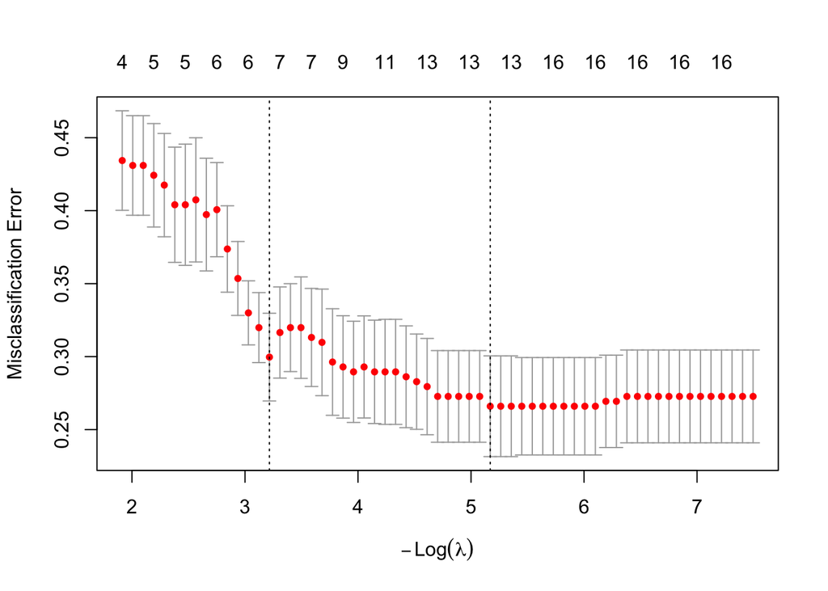

```r
# set so that covariates have a penalty factor of 0 so theyre always retained
penalty_factor <- rep(1, ncol(X))
penalty_factor[
  colnames(X) %in% c("age", "sexMale", "race_ethWhite non-Hispanic",
                     "race_ethHispanic")] <- 0
cvfit <- cv.glmnet(
  X, y,
  family = "binomial",
  alpha = 1,
  type.measure = "class",
  penalty.factor = penalty_factor)

plot(cvfit)
```

extract best model

```r
#coef(cvfit, s = "lambda.min")
coef(cvfit, s = "lambda.1se")
```

```
## 17 x 1 sparse Matrix of class "dgCMatrix"
##                              lambda.1se
## (Intercept)                -0.846543075
## age                         0.008722292
## sexMale                     0.046689817
## race_ethHispanic            0.377323236
## race_ethWhite non-Hispanic  0.249126490
## sinusitisYes                .
## diabetesYes                 0.172207750
## immunocompromiseYes         .
## `drug/alc`Yes               .
## asthmaYes                   .
## traumaYes                   .
## prior_surgeryYes            .
## dental_infectionYes         .
## `nldo/infection`Yes         .
## spaYes                      2.025184059
## oaYes                       0.718835155
## iceYes                      .
```

```r
# variables selected per cross-validation results
rownames(coef(cvfit, s = "lambda.1se"))[
  as.numeric(coef(cvfit, s = "lambda.1se")) != 0]
```

```
## [1] "(Intercept)"                "age"
## [3] "sexMale"                    "race_ethHispanic"
## [5] "race_ethWhite non-Hispanic" "diabetesYes"
## [7] "spaYes"                     "oaYes"
```

Predictions and model performance

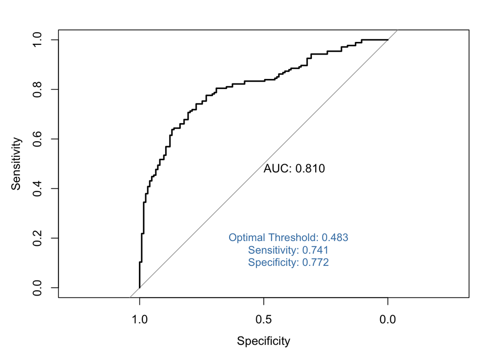

```r
pred_prob <- predict(cvfit, newx = X, s = "lambda.min", type = "response")
pred_class <- ifelse(pred_prob > 0.5, 1, 0)

# ROC curve - evaluate PC1 as a predictor of malignancy on test set
roc_obj = roc(y, pred_prob)
# Find optimal sensitivity, specificity, and threshold using Youden's method
opt_coords <- coords(roc_obj, "best",
                     ret = c("threshold", "sensitivity", "specificity"),
                     best.method = "youden")

# Plot the ROC curve and display the AUC
plot(roc_obj, print.auc = TRUE, xlim = c(1, 0), ylim = c(0, 1))
text(0.4, 0.20, paste("Optimal Threshold:", round(opt_coords$threshold, 3)),
     cex = 0.9, col = "steelblue")
text(0.4, 0.15, paste("Sensitivity:", round(opt_coords$sensitivity, 3)),
     cex = 0.9, col = "steelblue")
text(0.4, 0.10, paste("Specificity:", round(opt_coords$specificity, 3)),
     cex = 0.9, col = "steelblue")
```

```r
auc(roc_obj)
```

```
## Area under the curve: 0.8099
```

#### 2.3.2 Final Model

```r
# OR & 95% CI
fbm_tbl <- data.frame(
  #term = names(nfs.model.fbm$coefficients),
  OR = exp(nfs.model.fbm$coefficients),
  LL = exp(nfs.model.fbm$ci.lower),
  UL = exp(nfs.model.fbm$ci.upper),
  p_value = nfs.model.fbm$prob) %>%
  mutate(
    # % change in odds (per unit increase)
    pct_chg = (OR  - 1) * 100,
    pct_LL = (LL - 1) * 100,
    pct_UL = (UL - 1) * 100) %>%
  mutate(pct_ci = sprintf("(%.2f, %.2f)", pct_LL, pct_UL),
         OR_ci = sprintf("(%.2f, %.2f)", LL, UL))

fbm_tbl
```

```
##                                    OR          LL          UL      p_value
## (Intercept)                 0.1612717  0.02836619   0.8409763 3.012531e-02
## age                         1.0108393  0.99453600   1.0277055 1.942773e-01
## sexMale                     1.2180324  0.67532164   2.2170330 5.132482e-01
## race_ethHispanic            1.2588049  0.34394919   4.7779059 7.290322e-01
## race_ethWhite non-Hispanic  1.3689926  0.43513581   4.5276086 5.931814e-01
## sinusitisYes                1.4721438  0.80734969   2.7233545 2.082245e-01
## diabetesYes                 2.9685479  1.46264166   6.2089190 2.455386e-03
## immunocompromiseYes         1.0702001  0.51326355   2.2207943 8.554174e-01
## `drug/alc`Yes               0.8016523  0.35057575   1.8096752 5.950398e-01
## asthmaYes                   0.7316722  0.22099246   2.3331015 5.979559e-01
## traumaYes                   1.6435581  0.75184462   3.6262744 2.127617e-01
## prior_surgeryYes            0.8880998  0.36223014   2.1517382 7.924889e-01
## dental_infectionYes         0.9015256  0.29599458   2.6878860 8.519301e-01
## `nldo/infection`Yes         4.3554720  0.51496997  52.4147081 1.722190e-01
## spaYes                     38.4445556 12.09687127 194.2067822 1.887379e-15
## oaYes                       6.3451967  2.95653886  14.7134786 7.313191e-07
## iceYes                      1.8864066  0.43436665   9.2942063 3.993964e-01
##                                pct_chg     pct_LL       pct_UL
## (Intercept)                 -83.872834  -97.16338   -15.902371
## age                           1.083929   -0.54640     2.770545
## sexMale                      21.803237  -32.46784   121.703300
## race_ethHispanic             25.880492  -65.60508   377.790591
## race_ethWhite non-Hispanic   36.899263  -56.48642   352.760862
## sinusitisYes                 47.214383  -19.26503   172.335451
## diabetesYes                 196.854792   46.26417   520.891904
## immunocompromiseYes           7.020010  -48.67365   122.079434
## `drug/alc`Yes               -19.834770  -64.94242    80.967518
## asthmaYes                   -26.832777  -77.90075   133.310148
## traumaYes                    64.355809  -24.81554   262.627443
## prior_surgeryYes            -11.190020  -63.77699   115.173817
## dental_infectionYes          -9.847444  -70.40054   168.788599
## `nldo/infection`Yes         335.547197  -48.50300  5141.470811
## spaYes                     3744.455564 1109.68713 19320.678220
## oaYes                       534.519666  195.65389  1371.347858
## iceYes                       88.640657  -56.56334   829.420626
##                                         pct_ci           OR_ci
## (Intercept)                   (-97.16, -15.90)    (0.03, 0.84)
## age                              (-0.55, 2.77)    (0.99, 1.03)
## sexMale                       (-32.47, 121.70)    (0.68, 2.22)
## race_ethHispanic              (-65.61, 377.79)    (0.34, 4.78)
## race_ethWhite non-Hispanic    (-56.49, 352.76)    (0.44, 4.53)
## sinusitisYes                  (-19.27, 172.34)    (0.81, 2.72)
## diabetesYes                    (46.26, 520.89)    (1.46, 6.21)
## immunocompromiseYes           (-48.67, 122.08)    (0.51, 2.22)
## `drug/alc`Yes                  (-64.94, 80.97)    (0.35, 1.81)
## asthmaYes                     (-77.90, 133.31)    (0.22, 2.33)
## traumaYes                     (-24.82, 262.63)    (0.75, 3.63)
## prior_surgeryYes              (-63.78, 115.17)    (0.36, 2.15)
## dental_infectionYes           (-70.40, 168.79)    (0.30, 2.69)
## `nldo/infection`Yes          (-48.50, 5141.47)   (0.51, 52.41)
## spaYes                     (1109.69, 19320.68) (12.10, 194.21)
## oaYes                        (195.65, 1371.35)   (2.96, 14.71)
## iceYes                        (-56.56, 829.42)    (0.43, 9.29)
```

```r
nfs_tbl <- fbm_tbl %>%
  rownames_to_column("Predictor") %>%
  mutate(n_fbm= nrow(model.frame(nfs.model.fbm)),
      Predictor = recode(
        Predictor,
        "age" = "Age (per 1yr)",
        "sexMale" = "Sex (Male vs Female)",
        "race_ethHispanic" = "HL vs Blk non-HL",
        "race_ethWhite non-Hispanic" = "White non-HL vs Blk non-HL)",
        "sinusitisYes" = "Sinusitis (Yes vs No)",
        "diabetesYes" = "Diabetes (Yes vs No)",
        "immunocompromiseYes" = "Immuno (Yes vs No)",
        "`drug/alc`Yes" = "Drugs/Alcohol (Yes vs No)",
        "asthmaYes" = "Asthma (Yes vs No)",
        "traumaYes" = "Trauma (Yes vs No)",
        "prior_surgeryYes" = "Prior Surgery (Yes vs No)",
        "dental_infectionYes" = "Dental (Yes vs No)",
        "`nldo/infection`Yes" = "NLDO (Yes vs No)",
        "spaYes" = "SPA (Yes vs No)",
        "oaYes" = "OA (Yes vs No)",
        "iceYes" = "ICE (Yes vs No)")) %>%
  select(Predictor, n_fbm, OR, OR_ci, pct_chg, p_value) %>%
  filter(Predictor != "(Intercept)") %>%
  gt() %>%
  cols_label(
    n_fbm = "N",
    OR = "OR",
    pct_chg = "%Δ in Odds",
    OR_ci = "95% CI",
    p_value  = "P-value") %>%
  # tab_spanner(
  #   label = "Bayesian",
  #   columns = c(n_brm, bay_pct, bay_ci)) %>%
  fmt_number(columns = c(OR), decimals = 2) %>%
  fmt_number(columns = pct_chg, decimals = 1) %>%
  fmt_number(columns = p_value, decimals = 3) %>%
    # bold specific text
  tab_style(style = cell_text(weight = "bold"),
    locations = cells_stub(rows = everything())) %>%
  tab_style(style = cell_text(weight = "bold"),
    locations = cells_column_labels()) %>%
    # highlight significant predictors <0.05
  tab_style(style = cell_fill(color = "#FFF3CD"),
            locations = list(
              cells_body(rows = p_value < 0.05),
              cells_stub(rows = p_value < 0.05))) %>%
  # p-value formatting like your other tables
  text_transform(
    locations = cells_body(columns = p_value),
    fn = function(x) ifelse(as.numeric(x) < 0.001, "<0.001",
                            format(round(as.numeric(x), 3), nsmall = 3))) %>%
  tab_options(table.font.size = "small") %>%
  tab_source_note(
    source_note = "%Δ in Odds represents percent change in the odds of needing surgery
    in the predictor (computed as (OR − 1) × 100). Negative values indicate lower
    odds of surgical need.") %>%
  tab_source_note(
    source_note = "Variables with very large odds ratios (e.g., SPA) reflect
    near-complete separation; effect sizes should be interpreted clinically
    rather than numerically.") %>%
    tab_header(
    title = "Factors Associated with Need for Surgery Among Adults Admitted for OC",
    subtitle = "Firth Logistic Regression Analysis") %>%
  tab_options(
    table.font.size = "small",
    #heading.align = "left",
    data_row.padding = px(3),
    table.width = pct(85),
    table.border.top.width = px(2),
    table.border.bottom.width = px(2))

nfs_tbl
```

Factors Associated with Need for Surgery Among Adults Admitted for OC

Firth Logistic Regression Analysis

| Predictor | N | OR | 95% CI | %Δ in Odds | P-value |
| --- | --- | --- | --- | --- | --- |
| Age (per 1yr) | 297 | 1.01 | (0.99, 1.03) | 1.1 | 0.194 |
| Sex (Male vs Female) | 297 | 1.22 | (0.68, 2.22) | 21.8 | 0.513 |
| HL vs Blk non-HL | 297 | 1.26 | (0.34, 4.78) | 25.9 | 0.729 |
| White non-HL vs Blk non-HL) | 297 | 1.37 | (0.44, 4.53) | 36.9 | 0.593 |
| Sinusitis (Yes vs No) | 297 | 1.47 | (0.81, 2.72) | 47.2 | 0.208 |
| Diabetes (Yes vs No) | 297 | 2.97 | (1.46, 6.21) | 196.9 | 0.002 |
| Immuno (Yes vs No) | 297 | 1.07 | (0.51, 2.22) | 7.0 | 0.855 |
| Drugs/Alcohol (Yes vs No) | 297 | 0.80 | (0.35, 1.81) | −19.8 | 0.595 |
| Asthma (Yes vs No) | 297 | 0.73 | (0.22, 2.33) | −26.8 | 0.598 |
| Trauma (Yes vs No) | 297 | 1.64 | (0.75, 3.63) | 64.4 | 0.213 |
| Prior Surgery (Yes vs No) | 297 | 0.89 | (0.36, 2.15) | −11.2 | 0.792 |
| Dental (Yes vs No) | 297 | 0.90 | (0.30, 2.69) | −9.8 | 0.852 |
| NLDO (Yes vs No) | 297 | 4.36 | (0.51, 52.41) | 335.5 | 0.172 |
| SPA (Yes vs No) | 297 | 38.44 | (12.10, 194.21) | 3,744.5 | <0.001 |
| OA (Yes vs No) | 297 | 6.35 | (2.96, 14.71) | 534.5 | <0.001 |
| ICE (Yes vs No) | 297 | 1.89 | (0.43, 9.29) | 88.6 | 0.399 |

%Δ in Odds represents percent change in the odds of needing surgery in the predictor (computed as (OR − 1) × 100). Negative values indicate lower odds of surgical need.  
Variables with very large odds ratios (e.g., SPA) reflect near-complete separation; effect sizes should be interpreted clinically rather than numerically.

> SPA was strongly associated with surgery, with very high rates of surgery among affected patients